# homework-6

Claire Hemingway

October 23, 2016

Task 1: This is the function for the Z-proportion test!

```r
Z.prop.test<-function(p1,n1,p0,p2=0,n2=0,alternative="two.sided", conf.level=0.95){
  if(p2==0&&n2==0){
    if(alternative=="greater"){
      ph<-mean(p1)
      z<-(ph-p0)/sqrt(p0*(1-p0)/n1)
      p<-pnorm(z,lower.tail=FALSE)
      lowerCI<-ph-qnorm(conf.level)*sqrt(ph*(1-ph)/n1)
      upperCI<-ph-qnorm(0)*sqrt(ph*(1-ph)/n1)
      if((n1*p1)>5&&(n1*(1-p1))>5){
        distrib="check for data distribution"}
      else{
        distrib="data normally distributed (rule of thumb)"
      }
      output<-list(z.value = z, p.value=p,lowCi=lowerCI,upperCI=upperCI,distribution=distrib)
      return(output)
    }
    else if(alternative=="less"){
      ph<-mean(p1)
      z<-(ph-p0)/sqrt(p0*(1-p0)/n1)
      p<-pnorm(z,lower.tail=TRUE)
      lowerCI<-ph+qnorm(0)*sqrt(ph*(1-ph)/n1)
      upperCI<-ph+qnorm(conf.level)*sqrt(ph*(1-ph)/n1)
      if((n1*p1)>5&&(n1*(1-p1))>5){
        distrib="check for data distribution"}
      else{
        distrib="data normally distributed (rule of thumb)"
      }
      output<-list(z.value = z, p.value=p,lowerCi=lowerCI,upperCI=upperCI,distribution=distrib)
      return(output)
    }
    else if(alternative=="two.sided"){
      ph<-mean(p1)
      z<-(ph-p0)/sqrt(p0*(1-p0)/n1)
      p<-2*pnorm(-abs(z))
      lowerCI<-ph-qnorm((1-conf.level)/2)*sqrt(ph*(1-ph)/n1)
      upperCI<-ph+qnorm((1-conf.level)/2)*sqrt(ph*(1-ph)/n1)
      if((n1*p1)>5&&(n1*(1-p1))>5){
        distri="check for data distribution"}
      else{
        distrib="data normally distributed (rule of thumb)"
      }
      output<-list(z.value = z, p.value=p,lowerCi=lowerCI,upperCI=upperCI,distribution=distrib)
      return(output)
    }
  }
  else{
    if(alternative=="two.sided"){
      pst <- (sum(p1) + sum(p2))/(length(p1) + length(p2))
      ph1 <- mean(p1)
      ph2 <- mean(p2)
      dif<-ph1-ph2
      se1<-sqrt(ph1*(1-ph1)/n1)
      se2<-sqrt(ph2*(1-ph2)/n2)
      sdif<-sqrt(se1^2+se2^2)
      z <- (ph2 - ph1)/sqrt((pst * (1 - pst)) * (1/n1 + 1/n2))
      p <- (1 - pnorm(z, lower.tail = FALSE)) + pnorm(z, lower.tail = TRUE)
      upperCI<-dif+qnorm(conf.level)*sdif
      lowerCI<-dif-qnorm(conf.level)*sdif
      if((n1*p1)>5&&(n1*(1-p1)&&(n2*p2)>5&&(n2*(1-p2))>5)){
        distrib="check data distribution?"}
      else{
        distrib="data normally distributed (rule of thumb)"
      }
      output<-list(z.value = z, p.value=p,lowerCi=lowerCI,upperCI=upperCI,distribution=distrib)
      return(output)
    }
    else if (alternative=="less"){
      pst <- (sum(p1) + sum(p2))/(n1 + n2)
      ph1 <- mean(p1)
      ph2 <- mean(p2)
      dif<-ph1-ph2
      se1<-sqrt(ph1*(1-ph1)/n1)
      se2<-sqrt(ph2*(1-ph2)/n2)
      sdif<-sqrt(se1^2+se2^2)
      z <- (ph2 - ph1)/sqrt((pst * (1 - pst)) * (1/n1 + 1/n2))
      p <- 1 - pnorm(z, lower.tail = TRUE)
      lowerCI<-dif+qnorm(0)*sdif
      upperCI<-dif+qnorm(conf.level)*sdif
      if((n1*p1)>5&&(n1*(1-p1)&&(n2*p2)>5&&(n2*(1-p2))>5)){
        distrib="check data distribution?"}
      else{
        distrib="data normally distributed (rule of thumb)"
      }
      output<-list(z.value = z, p.value=p,lowerCi=lowerCI,upperCI=upperCI,distribution=distrib)
      return(output)
    }
    else if (alternative=="greater"){
      pst <- (sum(p1) + sum(p2))/(n1 + n2)
      ph1 <- mean(p1)
      ph2 <- mean(p2)
      dif<-ph1-ph2
      se1<-sqrt(ph1*(1-ph1)/n1)
      se2<-sqrt(ph2*(1-ph2)/n2)
      sdif<-sqrt(se1^2+se2^2)
      z <- (ph2 - ph1)/sqrt((pst * (1 - pst)) * (1/n1 + 1/n2))
      p <- 1 - pnorm(z, lower.tail = FALSE)
      lowerCI<-dif+qnorm(0)*sdif
      upperCI<-dif+qnorm(conf.level)*sdif
      if((n1*p1)>5&&(n1*(1-p1)&&(n2*p2)>5&&(n2*(1-p2))>5)){
        distrib="check data distribution?"}
      else{
        distrib="data normally distributed (rule of thumb)"
      }
      output<-list(z.value = z, p.value=p,lowerCi=lowerCI,upperCI=upperCI,distribution=distrib)
      return(output)
    }
  }
}
```

Task 2.1: Regression, fit the data and plot it (+ equation)

```r
library(curl)
```

```r
library(ggplot2)
d <- read.csv(curl("https://raw.githubusercontent.com/difiore/ADA2016/master/KamilarAndCooperData.csv"), header = TRUE, sep = ",", stringsAsFactors = FALSE)
head(d) # Uploaded dataset
```

```
##               Scientific_Name          Family          Genus      Species
## 1 Allenopithecus_nigroviridis Cercopithecidae Allenopithecus nigroviridis
## 2         Allocebus_trichotis Cercopithecidae      Allocebus    trichotis
## 3           Alouatta_belzebul        Atelidae       Alouatta     belzebul
## 4             Alouatta_caraya        Atelidae       Alouatta       caraya
## 5            Alouatta_guariba        Atelidae       Alouatta      guariba
## 6           Alouatta_palliata        Atelidae       Alouatta     palliata
##   Brain_Size_Species_Mean Brain_Size_Female_Mean   Brain_size_Ref
## 1                   58.02                  53.70 Isler et al 2008
## 2                      NA                     NA
## 3                   52.84                  51.19 Isler et al 2008
## 4                   52.63                  47.80 Isler et al 2008
## 5                   51.70                  49.08 Isler et al 2008
## 6                   49.88                  48.04 Isler et al 2008
##   Body_mass_male_mean Body_mass_female_mean Mass_Dimorphism
```

[output cut: 69 more lines]

```r
# Run the models for untransformed and log transformed and create labels for the regression lines.

model.untr<-lm(MaxLongevity_m~Brain_Size_Species_Mean, d)
summary(model.untr)
```

```
##
## Call:
## lm(formula = MaxLongevity_m ~ Brain_Size_Species_Mean, data = d)
##
## Residuals:
##     Min      1Q  Median      3Q     Max
## -198.27  -61.92  -17.78   56.16  331.36
##
## Coefficients:
##                         Estimate Std. Error t value Pr(>|t|)
## (Intercept)             248.9523    11.1111   22.41   <2e-16 ***
## Brain_Size_Species_Mean   1.2180     0.1101   11.06   <2e-16 ***
## ---
## Signif. codes:  0 '***' 0.001 '**' 0.01 '*' 0.05 '.' 0.1 ' ' 1
##
## Residual standard error: 90.91 on 126 degrees of freedom
##   (85 observations deleted due to missingness)
## Multiple R-squared:  0.4928, Adjusted R-squared:  0.4887
## F-statistic: 122.4 on 1 and 126 DF,  p-value: < 2.2e-16
```

```r
b0_ut<-signif(coef(model.untr)[1])
b1_ut<-signif(coef(model.untr)[2])
label.ut<-paste("y= ",b1_ut,"x+ ",b0_ut,sep="")

d$log.brainsize<-log(d$Brain_Size_Species_Mean)  # Create new columns of the log transformed values (brainsize)
d$log.longevity<-log(d$MaxLongevity_m)           # Create new columns of the log transformed values (longevity)
head(d)
```

```
##               Scientific_Name          Family          Genus      Species
## 1 Allenopithecus_nigroviridis Cercopithecidae Allenopithecus nigroviridis
## 2         Allocebus_trichotis Cercopithecidae      Allocebus    trichotis
## 3           Alouatta_belzebul        Atelidae       Alouatta     belzebul
## 4             Alouatta_caraya        Atelidae       Alouatta       caraya
## 5            Alouatta_guariba        Atelidae       Alouatta      guariba
## 6           Alouatta_palliata        Atelidae       Alouatta     palliata
##   Brain_Size_Species_Mean Brain_Size_Female_Mean   Brain_size_Ref
## 1                   58.02                  53.70 Isler et al 2008
## 2                      NA                     NA
## 3                   52.84                  51.19 Isler et al 2008
## 4                   52.63                  47.80 Isler et al 2008
## 5                   51.70                  49.08 Isler et al 2008
## 6                   49.88                  48.04 Isler et al 2008
##   Body_mass_male_mean Body_mass_female_mean Mass_Dimorphism
```

[output cut: 76 more lines]

```r
model.tr<-lm(log.longevity~log.brainsize, d)
summary(model.tr)
```

```
##
## Call:
## lm(formula = log.longevity ~ log.brainsize, data = d)
##
## Residuals:
##     Min      1Q  Median      3Q     Max
## -0.6955 -0.1750 -0.0097  0.1788  0.6084
##
## Coefficients:
##               Estimate Std. Error t value Pr(>|t|)
## (Intercept)    4.87895    0.06907   70.63   <2e-16 ***
## log.brainsize  0.23415    0.01781   13.15   <2e-16 ***
## ---
## Signif. codes:  0 '***' 0.001 '**' 0.01 '*' 0.05 '.' 0.1 ' ' 1
##
## Residual standard error: 0.2485 on 126 degrees of freedom
##   (85 observations deleted due to missingness)
## Multiple R-squared:  0.5784, Adjusted R-squared:  0.5751
## F-statistic: 172.9 on 1 and 126 DF,  p-value: < 2.2e-16
```

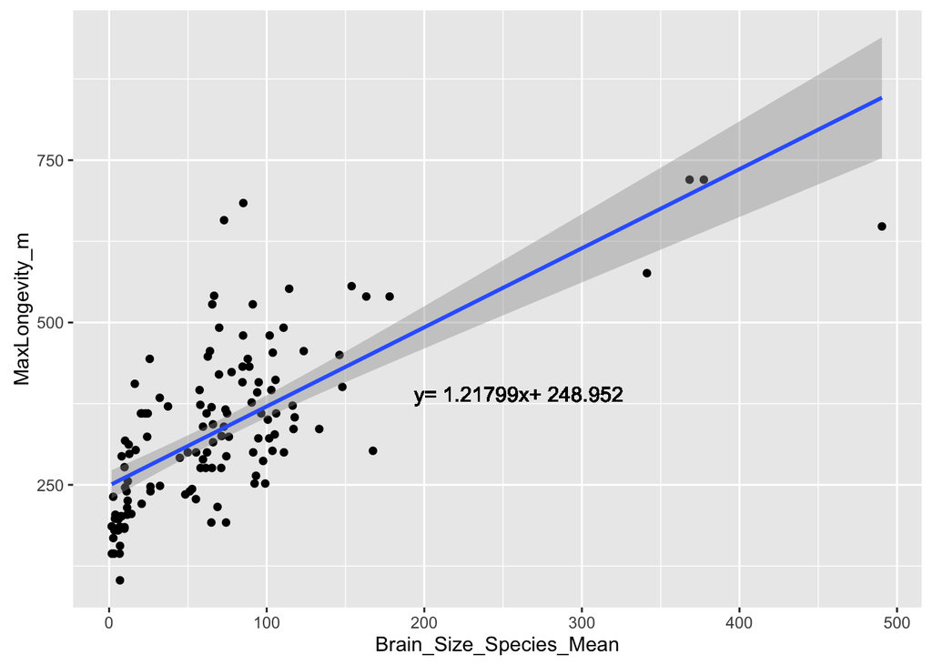

```r
b0_tr<-signif(coef(model.tr)[1])
b1_tr<-signif(coef(model.tr)[2])
label.tr<-paste("y= ",b1_tr,"x+ ",b0_tr,sep="")

# Plot the data + best fit regression + equation
# untransformed
put<- ggplot(data = d, aes(x = Brain_Size_Species_Mean, y = MaxLongevity_m))
put<-put+geom_point()
put<-put+geom_smooth(method = "lm", formula = y ~ x)
put<-put+geom_text(aes(x=260, y=390, label=label.ut),size=4,parse=FALSE)
put
```

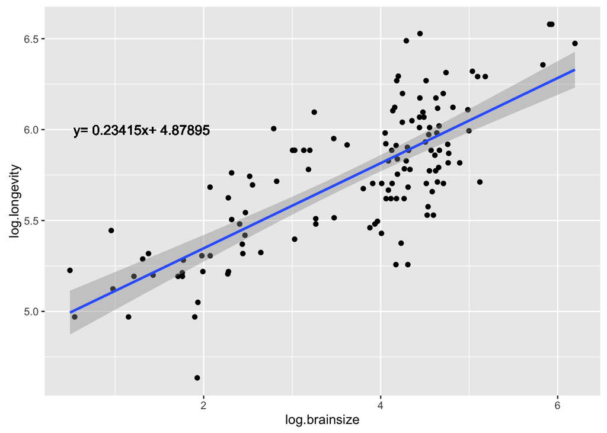

```r
# log transformed
ptr<-ggplot(data = d, aes(x = log.brainsize , y = log.longevity))
ptr<-ptr+geom_point()
ptr<-ptr+geom_smooth(method = "lm", formula = y ~ x)
ptr<-ptr+geom_text(aes(x=1.3, y=6.0, label=label.tr),size=4,parse=FALSE)
ptr
```

```r
# Slope, statistics and CI's for the untransformed dataset
b1_ut
```

```
## Brain_Size_Species_Mean
##                 1.21799
```

```r
summary(model.untr)
```

```
##
## Call:
## lm(formula = MaxLongevity_m ~ Brain_Size_Species_Mean, data = d)
##
## Residuals:
##     Min      1Q  Median      3Q     Max
## -198.27  -61.92  -17.78   56.16  331.36
##
## Coefficients:
##                         Estimate Std. Error t value Pr(>|t|)
## (Intercept)             248.9523    11.1111   22.41   <2e-16 ***
## Brain_Size_Species_Mean   1.2180     0.1101   11.06   <2e-16 ***
## ---
## Signif. codes:  0 '***' 0.001 '**' 0.01 '*' 0.05 '.' 0.1 ' ' 1
##
## Residual standard error: 90.91 on 126 degrees of freedom
##   (85 observations deleted due to missingness)
## Multiple R-squared:  0.4928, Adjusted R-squared:  0.4887
## F-statistic: 122.4 on 1 and 126 DF,  p-value: < 2.2e-16
```

```r
cIut<-confint(model.untr,level=0.95)
cIut
```

```
##                             2.5 %     97.5 %
## (Intercept)             226.96370 270.940834
## Brain_Size_Species_Mean   1.00013   1.435851
```

```r
# Slope, statistics and CI's for the log transformed dataset
b1_tr
```

```
## log.brainsize
##       0.23415
```

```r
summary(model.tr)
```

```
##
## Call:
## lm(formula = log.longevity ~ log.brainsize, data = d)
##
## Residuals:
##     Min      1Q  Median      3Q     Max
## -0.6955 -0.1750 -0.0097  0.1788  0.6084
##
## Coefficients:
##               Estimate Std. Error t value Pr(>|t|)
## (Intercept)    4.87895    0.06907   70.63   <2e-16 ***
## log.brainsize  0.23415    0.01781   13.15   <2e-16 ***
## ---
## Signif. codes:  0 '***' 0.001 '**' 0.01 '*' 0.05 '.' 0.1 ' ' 1
##
## Residual standard error: 0.2485 on 126 degrees of freedom
##   (85 observations deleted due to missingness)
## Multiple R-squared:  0.5784, Adjusted R-squared:  0.5751
## F-statistic: 172.9 on 1 and 126 DF,  p-value: < 2.2e-16
```

```r
CItr<-confint(model.tr, level=0.95)
CItr
```

```
##                   2.5 %    97.5 %
## (Intercept)   4.7422563 5.0156456
## log.brainsize 0.1989063 0.2693928
```

Interpretation: B1 is EXPECTED change in units of y for every 1 unit of change in x (longevity for every 1 unit of change in brain size).Both models (log transformed and untransformed) result in highly significant p-values against H0 that Beta1=0, and for the HA that Beta1 doesn’t equal zero.

```r
# untransformed
# calculate CI's and PI's for the untransformed brainsize + longevity
cut<-predict(model.untr,newdata=data.frame(Brain_Size_Species_Mean=d$Brain_Size_Species_Mean),interval="confidence", level=0.95)
head(cut)
```

```
##        fit      lwr      upr
## 1 319.6201 303.5156 335.7245
## 2       NA       NA       NA
## 3 313.3109 296.9899 329.6319
## 4 313.0551 296.7238 329.3864
## 5 311.9224 295.5437 328.3011
## 6 309.7056 293.2275 326.1838
```

```r
put<-predict(model.untr, newdata = data.frame(Brain_Size_Species_Mean=d$Brain_Size_Species_Mean), interval = "prediction",level = 0.95)
head(put)
```

```
##        fit      lwr      upr
## 1 319.6201 138.9907 500.2494
## 2       NA       NA       NA
## 3 313.3109 132.6621 493.9596
## 4 313.0551 132.4054 493.7048
## 5 311.9224 131.2684 492.5763
## 6 309.7056 129.0426 490.3686
```

```r
# connect everything in a data.frame
data<-cbind(d$Brain_Size_Species_Mean,d$MaxLongevity_m,cut,put)
data<-data.frame(data)
head(data)
```

```
##      V1    V2      fit      lwr      upr    fit.1    lwr.1    upr.1
## 1 58.02 276.0 319.6201 303.5156 335.7245 319.6201 138.9907 500.2494
## 2    NA    NA       NA       NA       NA       NA       NA       NA
## 3 52.84    NA 313.3109 296.9899 329.6319 313.3109 132.6621 493.9596
## 4 52.63 243.6 313.0551 296.7238 329.3864 313.0551 132.4054 493.7048
## 5 51.70    NA 311.9224 295.5437 328.3011 311.9224 131.2684 492.5763
## 6 49.88 300.0 309.7056 293.2275 326.1838 309.7056 129.0426 490.3686
```

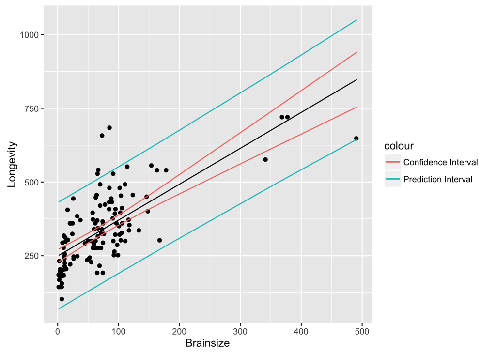

```r
colnames(data)<-c("Brainsize", "Longevity", "fit.CI", "lower.CI", "upper.CI","fit.PI", "lower.PI", "upper.PI")


plot.ut<- ggplot(data = data, aes(x = Brainsize, y = Longevity))
plot.ut<-plot.ut+geom_line(aes(x = Brainsize, y = fit.CI))
plot.ut<-plot.ut+geom_point()
plot.ut<-plot.ut+geom_line(aes(x = Brainsize, y = lower.CI,color="Confidence Interval"))
plot.ut<-plot.ut+geom_line(aes(x = Brainsize, y = upper.CI,color="Confidence Interval"))
plot.ut<-plot.ut+geom_line(aes(x=Brainsize, y=lower.PI,colour="Prediction Interval"))
plot.ut<-plot.ut+geom_line(aes(x=Brainsize, y=upper.PI,colour="Prediction Interval"))
plot.ut
```

```r
# log transformed
# calculate CI's and PI's for log transformed brainsize + longevity
ctr<-predict(model.tr,newdata=data.frame(log.brainsize=d$log.brainsize),interval="confidence", level=0.95)
head(ctr)
```

```
##        fit      lwr      upr
## 1 5.829783 5.784271 5.875294
## 2       NA       NA       NA
## 3 5.807885 5.763241 5.852529
## 4 5.806953 5.762340 5.851565
## 5 5.802778 5.758304 5.847253
## 6 5.794387 5.750163 5.838610
```

```r
ptr<-predict(model.tr, newdata = data.frame(log.brainsize=d$log.brainsize), interval = "prediction",level = 0.95)
head(ptr)
```

```
##        fit      lwr      upr
## 1 5.829783 5.335994 6.323571
## 2       NA       NA       NA
## 3 5.807885 5.314176 6.301595
## 4 5.806953 5.313246 6.300659
## 5 5.802778 5.309084 6.296472
## 6 5.794387 5.300715 6.288058
```

```r
# connect everything in a data.frame
data.tr<-cbind(d$log.brainsize,d$log.longevity,ctr,ptr)
data.tr<-data.frame(data.tr)
head(data.tr)
```

```
##         V1       V2      fit      lwr      upr    fit.1    lwr.1    upr.1
## 1 4.060788 5.620401 5.829783 5.784271 5.875294 5.829783 5.335994 6.323571
## 2       NA       NA       NA       NA       NA       NA       NA       NA
## 3 3.967268       NA 5.807885 5.763241 5.852529 5.807885 5.314176 6.301595
## 4 3.963286 5.495528 5.806953 5.762340 5.851565 5.806953 5.313246 6.300659
## 5 3.945458       NA 5.802778 5.758304 5.847253 5.802778 5.309084 6.296472
## 6 3.909620 5.703782 5.794387 5.750163 5.838610 5.794387 5.300715 6.288058
```

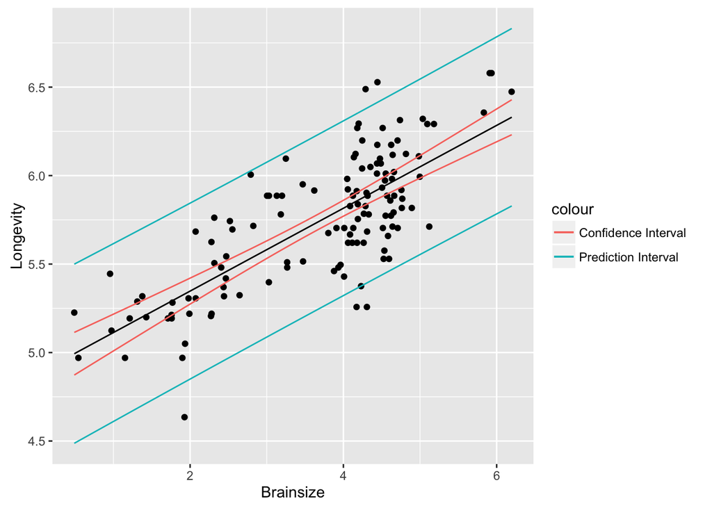

```r
colnames(data.tr)<-c("Brainsize", "Longevity", "fit.CI", "lower.CI", "upper.CI","fit.PI", "lower.PI", "upper.PI")


plot.tr<- ggplot(data = data.tr, aes(x = Brainsize, y = Longevity))
plot.tr<-plot.tr+geom_line(aes(x = Brainsize, y = fit.CI))
plot.tr<-plot.tr+geom_point()
plot.tr<-plot.tr+geom_line(aes(x = Brainsize, y = lower.CI,color="Confidence Interval"))
plot.tr<-plot.tr+geom_line(aes(x = Brainsize, y = upper.CI,color="Confidence Interval"))
plot.tr<-plot.tr+geom_line(aes(x=Brainsize, y=lower.PI,colour="Prediction Interval"))
plot.tr<-plot.tr+geom_line(aes(x=Brainsize, y=upper.PI,colour="Prediction Interval"))
plot.tr
```

Task 2.4: Produce a point estimate and associated 90 percent PI for the longevity of a species whose brain weight is 800 gm.Do you trust the model to predict observations accurately for this value of the explanatory variable? Why or why not?

```r
# untransformed
Untr<-predict(model.untr, newdata = data.frame(Brain_Size_Species_Mean = 800), interval = "prediction",level = 0.90)
Untr
```

```
##        fit      lwr      upr
## 1 1223.345 1021.805 1424.884
```

```r
# log transformed
Tr<-predict(model.tr, newdata = data.frame(log.brainsize = log(800)), interval = "prediction",level = 0.90)
Tr
```

```
##       fit      lwr      upr
## 1 6.44415 6.021424 6.866876
```

Interpretation: 90 % chance that the longevity of a species with brain mass 800 is between ~1021 and ~1424.Range for logtransformed dataset (~6.02 and ~6.86). Datapoints evenly distributed when log transformed. Linear relatinship of log transformed dataset seems to be clearer. Datapoints in untransformed dataset mostly located in “lower” area (small brain mass, short longevity).